# GEO 200CN Lab #4 Part 2

Kenneth Larrieu

April 26, 2019

```r
library(rspatial)
```

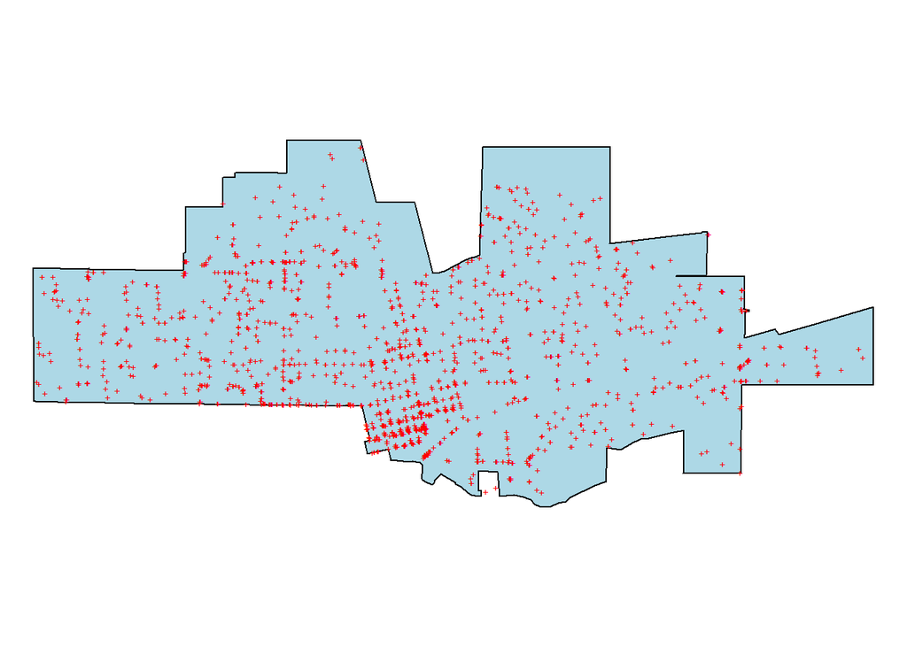

```r
# load data
city <- sp_data("city")
crime <- sp_data("crime.rds")
# plot it
par(mai=c(0,0,0,0))
plot(city, col='light blue')
points(crime, col='red', cex=.5, pch='+')
```

```r
tb <- sort(table(crime$CATEGORY))[-1]
# count for each type of crime
tb
```

```
##
##                Arson              Weapons              Robbery
##                    9                   15                   49
##           Auto Theft   Drugs or Narcotics  Commercial Burglary
##                   86                  134                  143
##          Grand Theft             Assaults                  DUI
##                  143                  172                  212
## Residential Burglary     Vehicle Burglary      Drunk in Public
##                  219                  221                  232
##            Vandalism          Petty Theft
##                  355                  665
```

```r
# get coordinates of crime incidents
xy <- coordinates(crime)
# only look at unique values
xy <- unique(xy)
```

```r
# get area of city
CityArea <- raster::area(city)
# density = crime locations per unit area
dens <- nrow(xy) / CityArea
dens
```

```
## [1] 4.36504e-06
```

```r
# check CRS of city to see what area units are
crs(city)
```

```
## CRS arguments:
##  +proj=lcc +lat_1=38.33333333333334 +lat_2=39.83333333333334
## +lat_0=37.66666666666666 +lon_0=-122 +x_0=2000000
## +y_0=500000.0000000001 +datum=NAD83 +units=us-ft +no_defs
## +ellps=GRS80 +towgs84=0,0,0
```

**Question 1a**: What is the unit of ‘dens’?

Looking at the coordinate reference system, we see the units of city are in ft. Therefore, the units of ‘dens’ are unique crime incident locations per square foot.

**Question 1b**: Question 1b:What is the number of crimes per km^2?

Using the total number of crimes rather than just crime locations, and using the area of the city in km^2:

```r
# change coordinate reference system units to km
km_crs = CRS("+proj=lcc +lat_1=38.33333333333334 +lat_2=39.83333333333334
+lat_0=37.66666666666666 +lon_0=-122 +x_0=2000000 +y_0=500000.0000000001
+datum=NAD83 +units=km +no_defs +ellps=GRS80 +towgs84=0,0,0")
city_km = spTransform(city, km_crs)

# recalculate area and density using km^2
CityArea_km <- raster::area(city_km)
# use total number of crimes, not just unique crime locationss
dens_km <- nrow(crime) / CityArea_km
# number of crimes per km^2
dens_km
```

```
## [1] 103.4986
```

```r
# make a raster from city extent
r <- raster(city)
# set resolution
res(r) <- 1000
r
```

```
## class       : RasterLayer
## dimensions  : 15, 34, 510  (nrow, ncol, ncell)
## resolution  : 1000, 1000  (x, y)
## extent      : 6620591, 6654591, 1956519, 1971519  (xmin, xmax, ymin, ymax)
## coord. ref. : +proj=lcc +lat_1=38.33333333333334 +lat_2=39.83333333333334 +lat_0=37.66666666666666 +lon_0=-122 +x_0=2000000 +y_0=500000.0000000001 +datum=NAD83 +units=us-ft +no_defs +ellps=GRS80 +towgs84=0,0,0
```

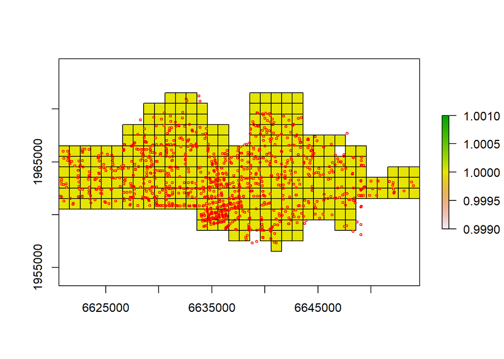

```r
# rasterize polygon plot quadrants
r <- rasterize(city, r)
plot(r)
quads <- as(r, 'SpatialPolygons')
plot(quads, add=TRUE)
# add points for crime locations
points(crime, col='red', cex=.5)
```

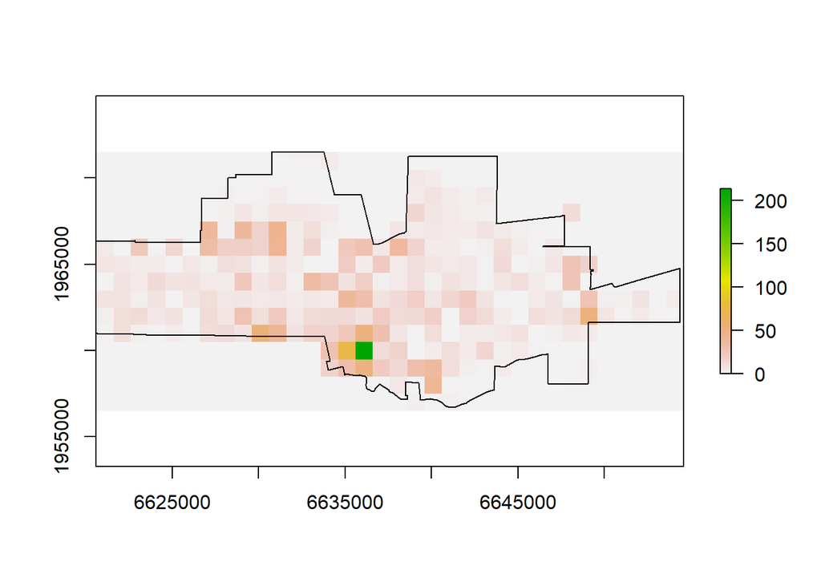

```r
# get quadrant counts
nc <- rasterize(coordinates(crime), r, fun='count', background=0)
plot(nc)
plot(city, add=TRUE)
```

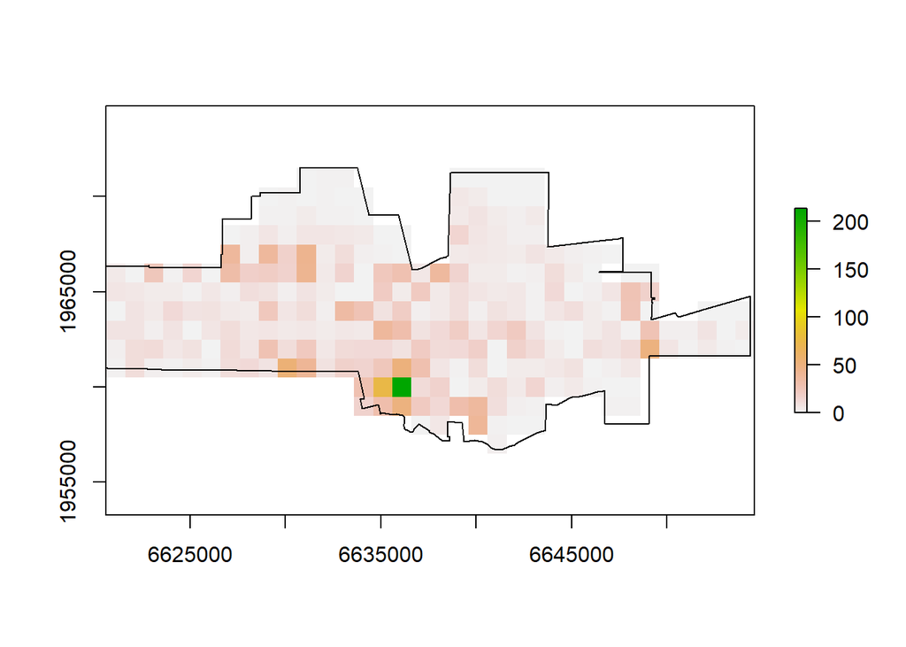

```r
# mask data outside city
ncrimes <- mask(nc, r)
plot(ncrimes)
plot(city, add=TRUE)
```

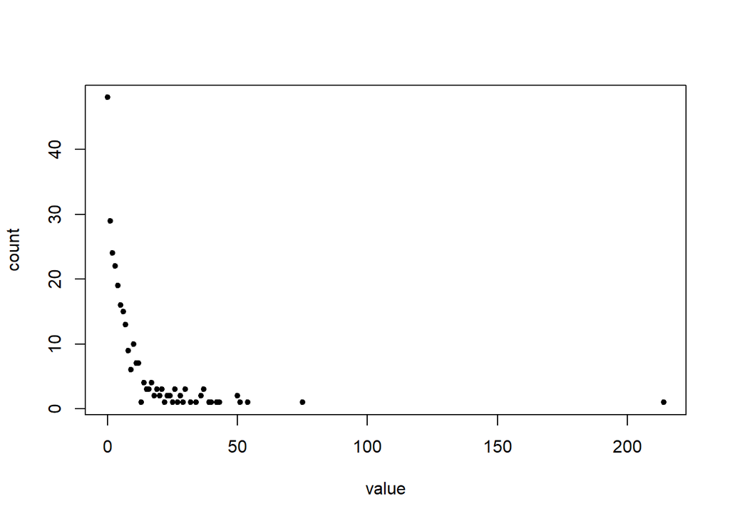

```r
# quadrant count frequency plot
f <- freq(ncrimes, useNA='no')
plot(f, pch=20)
```

```r
# number of quadrats
quadrats <- sum(f[,2])
# number of cases
cases <- sum(f[,1] * f[,2])
# mean cases per quadrant
mu <- cases / quadrats
mu
```

```
## [1] 9.261484
```

```r
# calculate variance using data.frame
ff <- data.frame(f)
colnames(ff) <- c('K', 'X')
ff$Kmu <- ff$K - mu
ff$Kmu2 <- ff$Kmu^2
ff$XKmu2 <- ff$Kmu2 * ff$X

# variance
s2 <- sum(ff$XKmu2) / (sum(ff$X)-1)
s2
```

```
## [1] 276.5555
```

```r
# variance to mean ratio
VMR <- s2 / mu
VMR
```

```
## [1] 29.86082
```

**Question 2**:What does this VMR score tell us about the point pattern?

The VMR of 29.86 suggests clustering and that the crime distribution is not an IRP, since the VMR is much larger than 1.

```r
# distance between crime coordinates
d <- dist(xy)
class(d)
```

```
## [1] "dist"
```

```r
# make into distance matrix
dm <- as.matrix(d)
dm[1:5, 1:5]
```

```
##           1        2         3         4         5
## 1     0.000 3980.843  8070.429  2455.809 10900.016
## 2  3980.843    0.000  4090.992  6303.450  6929.439
## 3  8070.429 4090.992     0.000 10375.958  2918.349
## 4  2455.809 6303.450 10375.958     0.000 13130.236
## 5 10900.016 6929.439  2918.349 13130.236     0.000
```

```r
# set diagonals (distance to self) as NA
diag(dm) <- NA
dm[1:5, 1:5]
```

```
##           1        2         3         4         5
## 1        NA 3980.843  8070.429  2455.809 10900.016
## 2  3980.843       NA  4090.992  6303.450  6929.439
## 3  8070.429 4090.992        NA 10375.958  2918.349
## 4  2455.809 6303.450 10375.958        NA 13130.236
## 5 10900.016 6929.439  2918.349 13130.236        NA
```

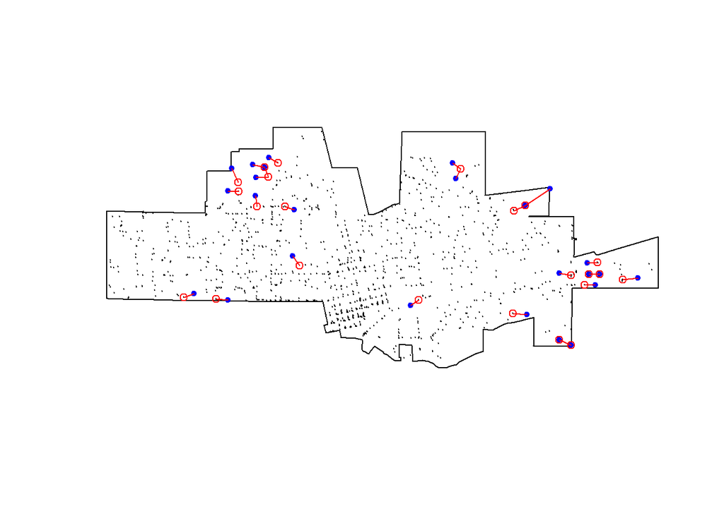

```r
# get minimum distance (dist to nearest neighbor)
dmin <- apply(dm, 1, min, na.rm=TRUE)
# mean minimum dist
mdmin <- mean(dmin)

wdmin <- apply(dm, 1, which.min)

plot(city)
points(crime, cex=.1)
ord <- rev(order(dmin))
far25 <- ord[1:25]
neighbors <- wdmin[far25]
points(xy[far25, ], col='blue', pch=20)
points(xy[neighbors, ], col='red')
# drawing the lines, easiest via a loop
for (i in far25) {
    lines(rbind(xy[i, ], xy[wdmin[i], ]), col='red')
}
```

```r
max(dmin)
```

```
## [1] 1829.738
```

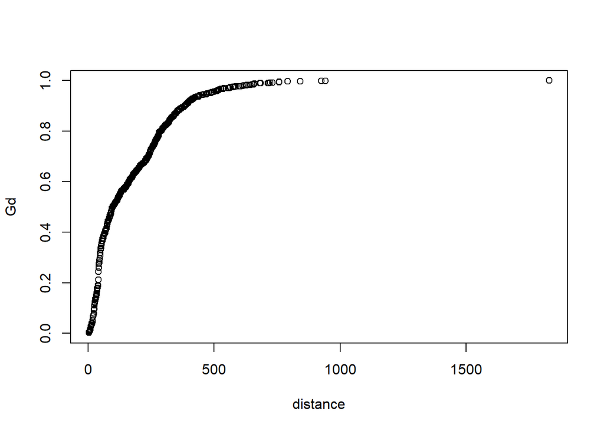

```r
# get the unique distances (for the x-axis)
distance <- sort(unique(round(dmin)))
# compute how many cases there with distances smaller that each x
Gd <- sapply(distance, function(x) sum(dmin < x))
# normalize to get values between 0 and 1
Gd <- Gd / length(dmin)
plot(distance, Gd)
```

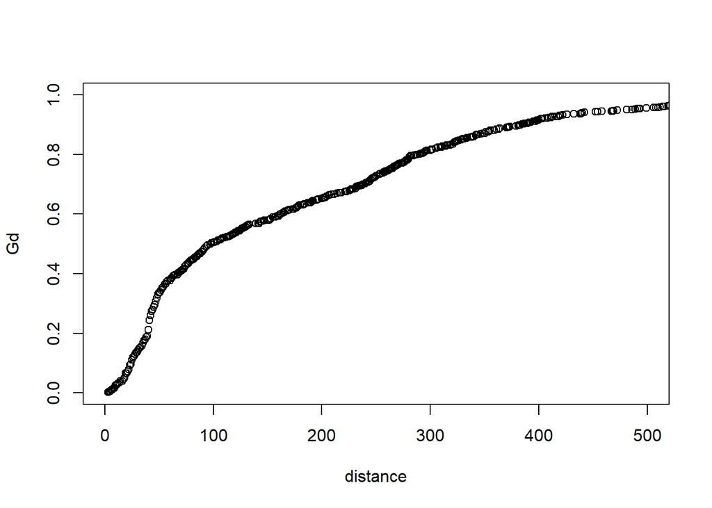

```r
# using xlim to exclude the extremes
plot(distance, Gd, xlim=c(0,500))
```

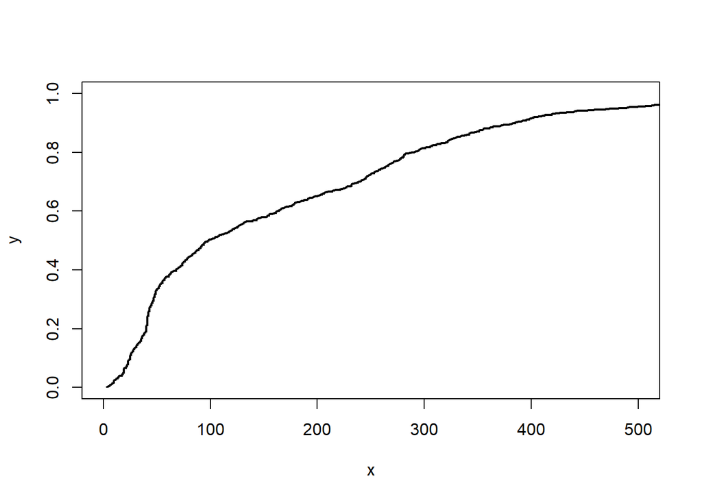

```r
# make step plot which looks much nicer
stepplot <- function(x, y, type='l', add=FALSE, ...) {
    x <- as.vector(t(cbind(x, c(x[-1], x[length(x)]))))
    y <- as.vector(t(cbind(y, y)))
  if (add) {
     lines(x,y, ...)
  } else {
       plot(x,y, type=type, ...)
  }
}

stepplot(distance, Gd, type='l', lwd=2, xlim=c(0,500))
```

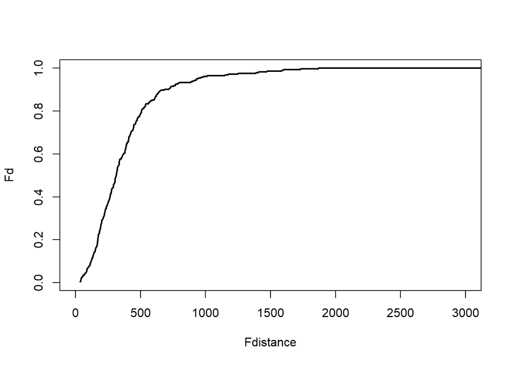

```r
# get the centers of the 'quadrats' (raster cells)
p <- rasterToPoints(r)
# compute distance from all crime sites to these cell centers
d2 <- pointDistance(p[,1:2], xy, longlat=FALSE)
# the remainder is similar to the G function
Fdistance <- sort(unique(round(d2)))
mind <- apply(d2, 1, min)
Fd <- sapply(Fdistance, function(x) sum(mind < x))
Fd <- Fd / length(mind)
plot(Fdistance, Fd, type='l', lwd=2, xlim=c(0,3000))
```

```r
ef <- function(d, lambda) {
  E <- 1 - exp(-1 * lambda * pi * d^2)
}
expected <- ef(0:2000, dens)
```

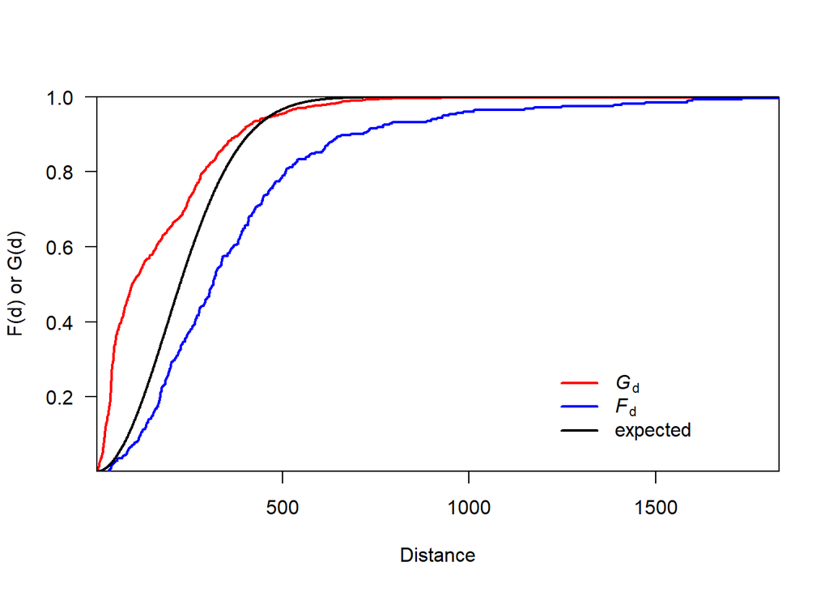

```r
plot(distance, Gd, type='l', lwd=2, col='red', las=1,
    ylab='F(d) or G(d)', xlab='Distance', yaxs="i", xaxs="i")
lines(Fdistance, Fd, lwd=2, col='blue')
lines(0:2000, expected, lwd=2)
legend(1200, .3,
   c(expression(italic("G")["d"]), expression(italic("F")["d"]), 'expected'),
   lty=1, col=c('red', 'blue', 'black'), lwd=2, bty="n")
```

**Question 3**: What does this plot suggest about the point pattern?

Because G is above the expected IRP distribution and F is below, this suggests that there is clutering in the data.

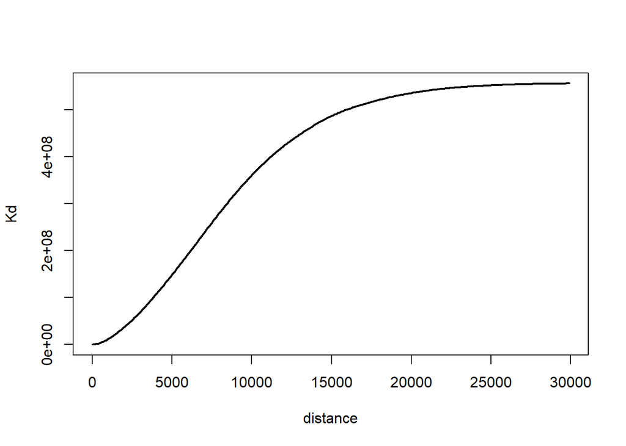

```r
distance <- seq(1, 30000, 100)
Kd <- sapply(distance, function(x) sum(d < x)) # takes a while
Kd <- Kd / (length(Kd) * dens)
plot(distance, Kd, type='l', lwd=2)
```

**Question 4**: Create a single random pattern of events for the city, with the same number of events as the crime data (object xy). Use function ‘spsample’.

```r
# random sample of points within city bounds with same number of events as xy
smpl = spsample(city, nrow(xy), "random")
```

**Question 5**: Compute the G function for the observed data, and plot it on a single plot, together with the G function for the theoretical expectation (formula 5.12).

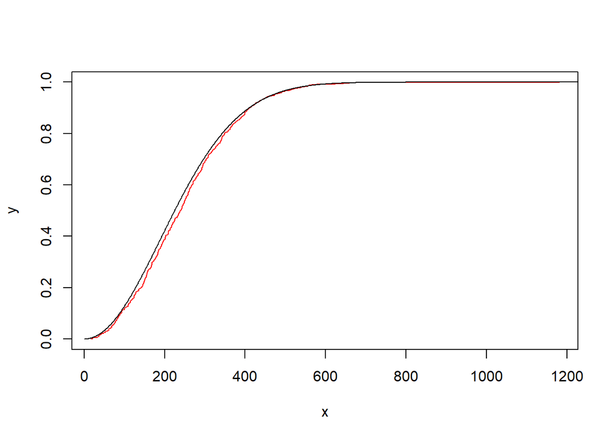

```r
smpl_coords = coordinates(smpl)
dm = as.matrix(dist(as.matrix(smpl_coords)))
diag(dm) = NA
dmin <- apply(dm, 1, min, na.rm=TRUE)
# get the unique distances (for the x-axis)
distance <- sort(unique(round(dmin)))
# compute how many cases there with distances smaller that each x
Gd <- sapply(distance, function(x) sum(dmin < x))
# normalize to get values between 0 and 1
Gd <- Gd / length(dmin)
stepplot(distance, Gd, col='red')
# density is the same as xy, so theoretical expectation of G is the same as for xy
lines(0:2000, expected)
legend(1200, .3,
   c(expression(italic("G")["d"]), 'expected'),
   lty=1, col=c('red', 'black'), lwd=2, bty="n")
```

**Question 6**: (Difficult!) Do a Monte Carlo simulation (page 149) to see if the ‘mean nearest distance’ of the observed crime data is significantly different from a random pattern. Use a ‘for loop’. First write ‘pseudo-code’. That is, say in natural language what should happen. Then try to write R code that implements this.

pseudo-code:

in for loop (doing 1000 times): generate random sample points within city compute mean nearest neighbor distance for the sample save the value to a dataframe

then, plot the distribution, and calculate mean and variance. Use this to describe the likelihood that the mean nearest distance for crime is significantly different from the random distribution.

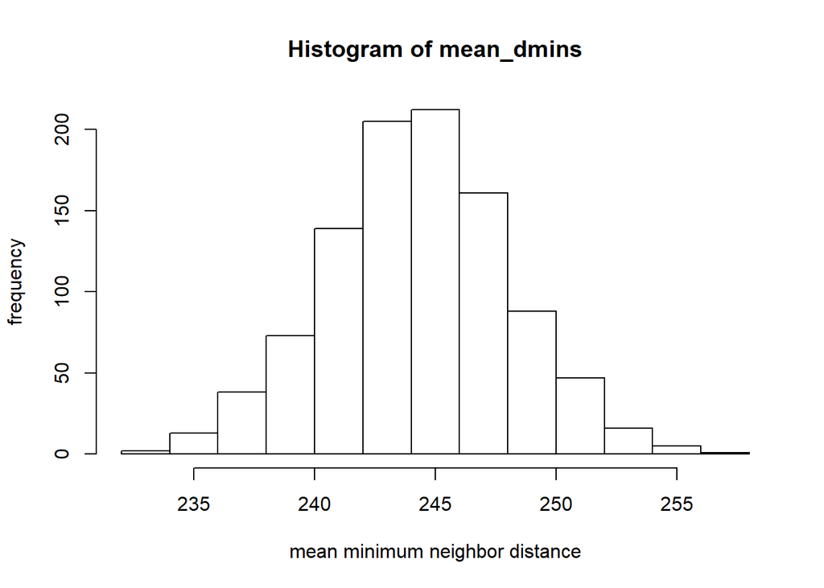

```r
# initialize array
mean_dmins = c()

for (i in 1:1000)
{
  # generate random sampling
  smpl = spsample(city, nrow(xy), "random")
  # get distances between points
  d = as.matrix(dist(coordinates(smpl)))
  # ignore distances to self
  diag(d) = NA
  # get minimum distances
  dmin <- apply(d, 1, min, na.rm=TRUE)
  # get average min distance
  avg = mean(dmin)
  # save value to array
  mean_dmins[i] = avg
}

mu = mean(mean_dmins)
sigma = sd(mean_dmins)

hist(mean_dmins, xlab="mean minimum neighbor distance", ylab="frequency")
```

```r
# number of standard deviations our crime data (xy) mean minimum distance is from mean of sampled distributions
devs = (mdmin - mu)/sigma
```

The distribution appears approximately normal with a mean of 244 and standard deviation of 3.81 Because the mean minimum distance for our crime data is approximately -20 standard deviations smaller than the expected value, we can conclude that the mean minimum distance between crime locations is significantly different from that expected from a random pattern.

**Question 7**: Why is the result surprising, or not surprising?